# Linear Regression and Variable Selection

BSAN 400

March 21, 2019

We use Boston Housing Data as an illustrative example in this lab. We learn basic linear regression and analysis with R.

Code in this file is not the only correct way to do things, however it is important for you to understand what each statement does. Mostly, only the basic commands are introduced, but you are recommended to explore and study yourself.

### Load Data

Boston housing data is a built-in dataset in `MASS` package, so you do not need to download externally. Package `MASS` comes with R when you installed R, so no need to use `install.packages(MASS)` to download and install, but you do need to load this package.

```r
library(MASS)
data(Boston) #this data is in MASS package
```

You can find details of the dataset from help document.

```r
?Boston
```

This is not for general use, because most time your dataset is not built-in.

## EDA

We have introduced many EDA techniques in lab 2. We will briefly go through some of them here.

```r
dim(Boston)
```

```
## [1] 506  14
```

```r
names(Boston)
```

```
##  [1] "crim"    "zn"      "indus"   "chas"    "nox"     "rm"      "age"
##  [8] "dis"     "rad"     "tax"     "ptratio" "black"   "lstat"   "medv"
```

```r
str(Boston)
```

```
## 'data.frame':    506 obs. of  14 variables:
##  $ crim   : num  0.00632 0.02731 0.02729 0.03237 0.06905 ...
##  $ zn     : num  18 0 0 0 0 0 12.5 12.5 12.5 12.5 ...
##  $ indus  : num  2.31 7.07 7.07 2.18 2.18 2.18 7.87 7.87 7.87 7.87 ...
##  $ chas   : int  0 0 0 0 0 0 0 0 0 0 ...
##  $ nox    : num  0.538 0.469 0.469 0.458 0.458 0.458 0.524 0.524 0.524 0.524 ...
##  $ rm     : num  6.58 6.42 7.18 7 7.15 ...
##  $ age    : num  65.2 78.9 61.1 45.8 54.2 58.7 66.6 96.1 100 85.9 ...
##  $ dis    : num  4.09 4.97 4.97 6.06 6.06 ...
##  $ rad    : int  1 2 2 3 3 3 5 5 5 5 ...
##  $ tax    : num  296 242 242 222 222 222 311 311 311 311 ...
##  $ ptratio: num  15.3 17.8 17.8 18.7 18.7 18.7 15.2 15.2 15.2 15.2 ...
##  $ black  : num  397 397 393 395 397 ...
##  $ lstat  : num  4.98 9.14 4.03 2.94 5.33 ...
##  $ medv   : num  24 21.6 34.7 33.4 36.2 28.7 22.9 27.1 16.5 18.9 ...
```

```r
summary(Boston)
```

```
##       crim                zn             indus            chas
##  Min.   : 0.00632   Min.   :  0.00   Min.   : 0.46   Min.   :0.00000
##  1st Qu.: 0.08204   1st Qu.:  0.00   1st Qu.: 5.19   1st Qu.:0.00000
##  Median : 0.25651   Median :  0.00   Median : 9.69   Median :0.00000
##  Mean   : 3.61352   Mean   : 11.36   Mean   :11.14   Mean   :0.06917
##  3rd Qu.: 3.67708   3rd Qu.: 12.50   3rd Qu.:18.10   3rd Qu.:0.00000
##  Max.   :88.97620   Max.   :100.00   Max.   :27.74   Max.   :1.00000
##       nox               rm             age              dis
##  Min.   :0.3850   Min.   :3.561   Min.   :  2.90   Min.   : 1.130
##  1st Qu.:0.4490   1st Qu.:5.886   1st Qu.: 45.02   1st Qu.: 2.100
##  Median :0.5380   Median :6.208   Median : 77.50   Median : 3.207
##  Mean   :0.5547   Mean   :6.285   Mean   : 68.57   Mean   : 3.795
##  3rd Qu.:0.6240   3rd Qu.:6.623   3rd Qu.: 94.08   3rd Qu.: 5.188
##  Max.   :0.8710   Max.   :8.780   Max.   :100.00   Max.   :12.127
##       rad              tax           ptratio          black
##  Min.   : 1.000   Min.   :187.0   Min.   :12.60   Min.   :  0.32
##  1st Qu.: 4.000   1st Qu.:279.0   1st Qu.:17.40   1st Qu.:375.38
##  Median : 5.000   Median :330.0   Median :19.05   Median :391.44
##  Mean   : 9.549   Mean   :408.2   Mean   :18.46   Mean   :356.67
##  3rd Qu.:24.000   3rd Qu.:666.0   3rd Qu.:20.20   3rd Qu.:396.23
##  Max.   :24.000   Max.   :711.0   Max.   :22.00   Max.   :396.90
##      lstat            medv
##  Min.   : 1.73   Min.   : 5.00
##  1st Qu.: 6.95   1st Qu.:17.02
##  Median :11.36   Median :21.20
##  Mean   :12.65   Mean   :22.53
##  3rd Qu.:16.95   3rd Qu.:25.00
##  Max.   :37.97   Max.   :50.00
```

We skip the Exploratory Data Analysis (EDA) in this notes, but you should not omit it in your HW and Cases. EDA is very important and always the first analysis to do before any modeling.

## Preparation

### Splitting data to training and testing samples

**This is one of the principles of data mining and machine learning.**

We sample 90% of the original data and use it as the training set. The remaining 10% is used as test set. The regression model will be built on the training set and future performance of your model will be evaluated with the test set.

```r
index <- sample(nrow(Boston),nrow(Boston)*0.90)
Boston.train <- Boston[index,]
Boston.test <- Boston[-index,]
```

### (Optional) Standardization

If we want our results to be invariant to the units and the parameter estimates $\beta_i$ to be comparible, we can standardize the variables. Essentially we are replacing the original values with their z-score.

1st Way: create new variables manually.

```r
Boston$sd.crim <- (Boston$crim-mean(Boston$crim))/sd(Boston$crim);
```

2nd Way: Use `scale()` function.

```r
Boston$sd.crim <- scale(Boston$crim);
```

Usually, if necessary, you may want to standardize all covariates (explanatory variabls)

```r
Boston[,-14]<- scale(Boston[,-14])
```

The technique is not as important in linear regression because it will only affect the interpretation but not the model estimation and inference.

## Model Building

### Simple linear regression

#### Model Estimation and Inference

We first fit a simple linear regression using, say “lstat”, as the explanatory variable $X$.

```r
# draw a scatter plot
plot(medv~lstat, data=Boston.train)
# fit the simple linear regression
model0<- lm(medv~lstat, data = Boston.train)
model0
```

```
##
## Call:
## lm(formula = medv ~ lstat, data = Boston.train)
##
## Coefficients:
## (Intercept)        lstat
##      34.650       -0.955
```

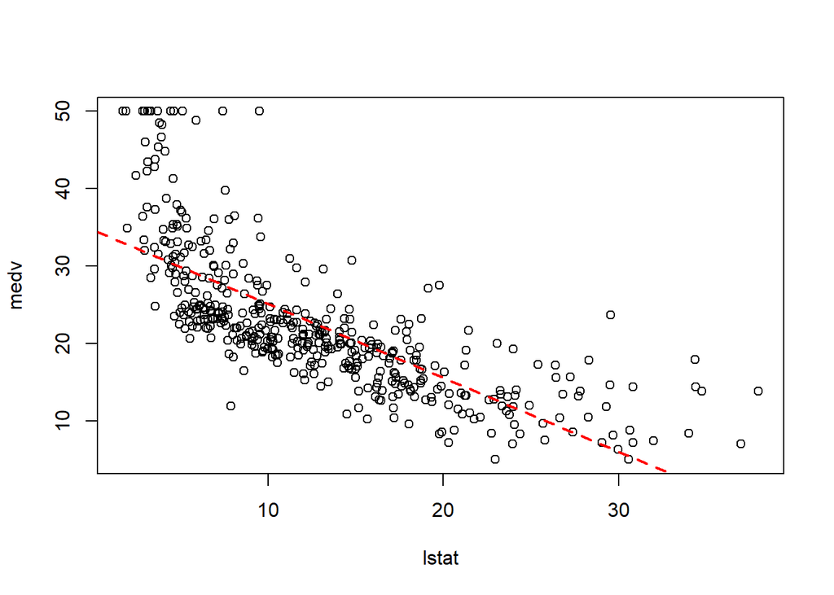

```r
abline(model0, col="red", lty=2, lwd=2)
```

To get more detailed outputs of the fitted model, we use function `summary()`.

```r
sum.model0<- summary(model0)
sum.model0
```

```
##
## Call:
## lm(formula = medv ~ lstat, data = Boston.train)
##
## Residuals:
##     Min      1Q  Median      3Q     Max
## -15.225  -4.068  -1.256   2.102  24.451
##
## Coefficients:
##             Estimate Std. Error t value Pr(>|t|)
## (Intercept) 34.64986    0.59146   58.58   <2e-16 ***
## lstat       -0.95496    0.04078  -23.42   <2e-16 ***
## ---
## Signif. codes:  0 '***' 0.001 '**' 0.01 '*' 0.05 '.' 0.1 ' ' 1
##
## Residual standard error: 6.261 on 453 degrees of freedom
## Multiple R-squared:  0.5476, Adjusted R-squared:  0.5466
## F-statistic: 548.4 on 1 and 453 DF,  p-value: < 2.2e-16
```

Note that both of the objects “model1” and “sum.model1” are lists. Therefore, we can extract any components in that list.

```r
model0$coefficients
```

```
## (Intercept)       lstat
##   34.649855   -0.954963
```

```r
sum.model0$adj.r.squared
```

```
## [1] 0.5466297
```

You may get the confidence interval for the estimated coefficients. Recall the formula to calculate the confidence interval: $\hat{\beta}_j \pm t_{\alpha/2, n-p-1}\times SE(\hat{\beta}_j)$.

```r
confint(model0)
```

```
##                 2.5 %     97.5 %
## (Intercept) 33.487505 35.8122063
## lstat       -1.035104 -0.8748225
```

#### Prediction

To predict “medv” given new set of covariates, we use function `predict()`.

```r
pred.model0<- predict(model0, newdata = Boston.test)
```

Be careful that the argument “newdata” has to be a dataframe. You can always convert a table, vector or matrix to a dataframe using `data.frame()`.

```r
predict(model0, newdata = data.frame(lstat=c(5,10,15)), interval = "confidence")
```

```
##        fit      lwr      upr
## 1 29.87504 29.03665 30.71343
## 2 25.10023 24.48716 25.71329
## 3 20.32541 19.71719 20.93363
```

### Multiple linear regreesion

The following model includes all $x$ varables in the model

```r
model1<- lm(medv~crim+zn+indus+chas+nox+rm+age+dis+rad+tax+ptratio+black+lstat, data=Boston.train)
# more convenient way
model1<- lm(medv~., data=Boston.train)
# summary
summary(model1)
```

```
##
## Call:
## lm(formula = medv ~ ., data = Boston.train)
##
## Residuals:
##      Min       1Q   Median       3Q      Max
## -14.8309  -2.6450  -0.5443   1.9793  26.7001
##
## Coefficients:
##               Estimate Std. Error t value Pr(>|t|)
## (Intercept)  37.321831   5.382776   6.934 1.47e-11 ***
## crim         -0.099378   0.034289  -2.898 0.003940 **
## zn            0.043380   0.014304   3.033 0.002566 **
## indus         0.046185   0.067340   0.686 0.493172
## chas          2.075301   0.930423   2.230 0.026217 *
## nox         -19.250096   4.025034  -4.783 2.36e-06 ***
## rm            3.939544   0.438596   8.982  < 2e-16 ***
## age           0.003229   0.013877   0.233 0.816123
## dis          -1.451940   0.207954  -6.982 1.08e-11 ***
## rad           0.322015   0.072096   4.466 1.01e-05 ***
## tax          -0.014668   0.004144  -3.539 0.000444 ***
## ptratio      -0.991790   0.137000  -7.239 2.02e-12 ***
## black         0.009448   0.002842   3.324 0.000961 ***
## lstat        -0.510645   0.054248  -9.413  < 2e-16 ***
## ---
## Signif. codes:  0 '***' 0.001 '**' 0.01 '*' 0.05 '.' 0.1 ' ' 1
##
## Residual standard error: 4.721 on 441 degrees of freedom
## Multiple R-squared:  0.7496, Adjusted R-squared:  0.7422
## F-statistic: 101.6 on 13 and 441 DF,  p-value: < 2.2e-16
```

Are there any insignificant variables?

```r
model2<- lm(medv~. -indus -age, data=Boston.train)
summary(model2)
```

```
##
## Call:
## lm(formula = medv ~ . - indus - age, data = Boston.train)
##
## Residuals:
##      Min       1Q   Median       3Q      Max
## -14.8739  -2.6542  -0.5521   1.9325  26.8520
##
## Coefficients:
##               Estimate Std. Error t value Pr(>|t|)
## (Intercept)  36.977563   5.339827   6.925 1.54e-11 ***
## crim         -0.100350   0.034206  -2.934 0.003523 **
## zn            0.041634   0.014047   2.964 0.003200 **
## chas          2.156727   0.921482   2.340 0.019701 *
## nox         -18.230435   3.704602  -4.921 1.22e-06 ***
## rm            3.933761   0.426745   9.218  < 2e-16 ***
## dis          -1.495031   0.193447  -7.728 7.37e-14 ***
## rad           0.306769   0.068833   4.457 1.06e-05 ***
## tax          -0.013358   0.003697  -3.613 0.000338 ***
## ptratio      -0.978435   0.135374  -7.228 2.17e-12 ***
## black         0.009443   0.002829   3.338 0.000914 ***
## lstat        -0.503377   0.050958  -9.878  < 2e-16 ***
## ---
## Signif. codes:  0 '***' 0.001 '**' 0.01 '*' 0.05 '.' 0.1 ' ' 1
##
## Residual standard error: 4.713 on 443 degrees of freedom
## Multiple R-squared:  0.7493, Adjusted R-squared:  0.7431
## F-statistic: 120.4 on 11 and 443 DF,  p-value: < 2.2e-16
```

#### Exercise:

1. get the predicted value of these two models, and calculate mean squared prediction error (MSPE)

```r
pred.model1<-
pred.model2<-
mspe.model1<-
mspe.model2<-
```

2. Estimate the regression model and make predictions without using function `lm()` and `predict()`.

## Model diagnostics

The aim of model diagnostics is to check if the model assumptions are valid. Recall that residual plot is primary tool for model diagnostics.

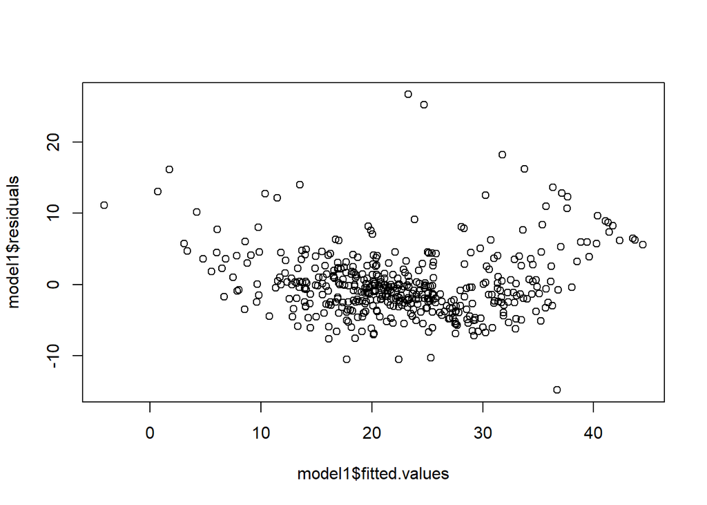

```r
plot(model1$fitted.values, model1$residuals)
```

What can you see from this plot?

More plots for model diagnostics.

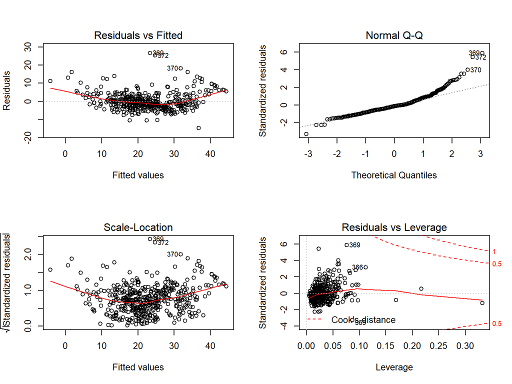

```r
#par(mar=c(4,4.5,2,1), oma=c(2,1,1,2))
par(mfrow=c(2,2)) # to specify the figure layout
plot(model1)
```

**HW bonus problem**: try to address the quadratic issue. (Hint: find possible variables that may have quadratic relationship to the response, and build new model.) Note that you need to include this new model as a candidate model and do the model comparison.

## Model Assessment

Suppose that everything in model diagnostics is okay. In other words, the model we have built is fairly a valid model. Then we need to evaluate the model performance in terms of different metrics.

Commonly used metrics include **MSE, (adjusted) $R^2$, AIC, BIC** for in-sample performance, and **MSPE, CV score** for out-of-sample performance.

### In-sample performance

```r
sum.model1<- summary(model1)
# MSE
(sum.model1$sigma)^2
```

```
## [1] 22.28557
```

```r
# by formula
sum(model1$residuals^2)/(nrow(Boston.train)-13-1)
```

```
## [1] 22.28557
```

$R^2$ of the model

```r
sum.model1$r.squared
```

```
## [1] 0.7496078
```

```r
sum.model1$adj.r.squared
```

```
## [1] 0.7422266
```

AIC and BIC of the model, these are information criteria. Smaller values indicate better fit.

```r
AIC(model1)
```

```
## [1] 2719.307
```

```r
BIC(model1)
```

```
## [1] 2781.111
```

BIC, AIC, and Adjusted $R^2$ have complexity penalty in the definition, thus when comparing across different models they are better indicators on how well the model will perform on future data.

### Out-of-sample prediction (test error)

#### For a single testing sample:

Recall the exercise problem…

```r
pred.model1<-
pred.model2<-
mpse.model1<-
mpse.model2<-
```

### Cross-validation

Instead of fitting a model on a pre-specified 90% training sample and evaluate the MSPE on the hold-out 10% testing sample, it is more reliable to use cross-validation for out-of-sample performance evaluation. For k-fold cross-validation, the dataset is divided into k parts (equal sample size). Each part serves as the testing sample in and the rest (k-1 together) serves as training sample. This training/testing procedure is iteratively performed k times. The CV score is usually the average of the metric of out-of-sample performance across k iterations.

Note

1. We use the **entire** dataset for cross validation
2. We need to use `glm()` instead of `lm()` to fit the model (if we want to use cv.glm function in boot package)
3. The default cost is the Mean Squared Prediction Error (MSPE). If we want to use another measure we need to define a cost function.

10-fold Cross Validation

```r
library(boot)
model.glm1 = glm(medv~., data = Boston)
cv.glm(data = Boston, glmfit = model.glm1, K = 10)$delta[2]
```

```
## [1] 24.15165
```

Comparing with model 2

```r
model.glm2 = glm(medv~. -indus -age, data = Boston)
cv.glm(data = Boston, glmfit = model.glm2, K = 10)$delta[2]
```

```
## [1] 23.3082
```

LOOCV (Leave-one-out Cross Validation)

```r
cv.glm(data = Boston, glmfit = model.glm1, K = nrow(Boston))$delta[2]
```

Now we define a MAD cost function as the CV score. The function takes 2 input vectors, pi = predicted values, r = actual values.

```r
MAD_cost = function(pi, r){
  return(mean(abs(pi-r)))
}
cv.glm(data = Boston, glmfit = model.glm1, cost = MAD_cost, K = 10)$delta[2]
```

```
## [1] 3.420198
```

**Exercise**: Do 10-fold cross-validation for all candidate models, and compare the CV score in terms of MSE and MAE.

## Bootstrapping

Bootstrapping is one of the most useful inventions in statistics. It is based on **random sampling with replacement**. We can use this technique to construct confidence intervals empirically.

```r
library(boot)
coef.lm<- function(formula, data, indices) {
  d <- data[indices,] # allows boot to select sample
  fit <- lm(formula, data=d)
  return(fit$coef)
}
# bootstrapping with 1000 replications
results <- boot(data=Boston, statistic=coef.lm, R=1000, formula=medv~.)

# view results
results
```

```
##
## ORDINARY NONPARAMETRIC BOOTSTRAP
##
##
## Call:
## boot(data = Boston, statistic = coef.lm, R = 1000, formula = medv ~
##     .)
##
##
## Bootstrap Statistics :
##           original        bias    std. error
## t1*   3.645949e+01 -8.013766e-01 8.050936599
## t2*  -1.080114e-01  3.759555e-03 0.034563365
## t3*   4.642046e-02 -1.936868e-03 0.013878478
## t4*   2.055863e-02 -2.136981e-03 0.050233476
## t5*   2.686734e+00  5.048394e-02 1.267197970
## t6*  -1.776661e+01  2.164431e-01 3.871107392
## t7*   3.809865e+00  9.192046e-02 0.825882177
## t8*   6.922246e-04 -1.346525e-03 0.016735375
## t9*  -1.475567e+00  4.091913e-03 0.220356614
## t10*  3.060495e-01 -4.074731e-03 0.061278190
## t11* -1.233459e-02  4.778883e-05 0.002723064
## t12* -9.527472e-01  5.792634e-03 0.120755782
## t13*  9.311683e-03  7.207989e-05 0.002679623
## t14* -5.247584e-01  6.203327e-03 0.098275335
```

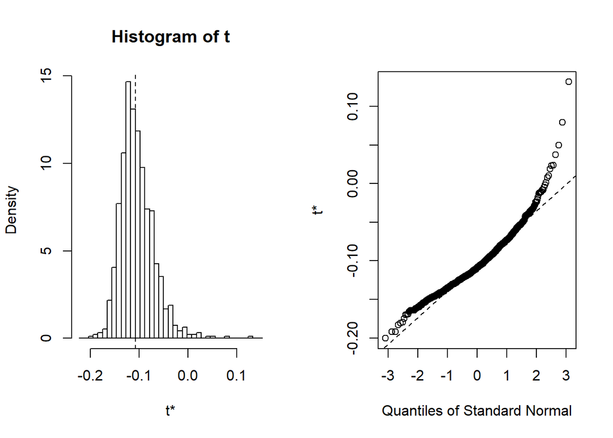

```r
plot(results, index = 2)
```

## Summary

From this lab, you should be able to use basic functions to conduct linear regression analysis. Testing sample is always important for any data mining analysis. You should care about the testing error more than training error. Cross-validation is a very use tool to evaluate testing error.

### Things to remember

- Random sampling (training vs. testing)
- `lm()` function for linear regression model fitting
- How to get different metrics about model fitting
- `predict()` function for prediction
- `cv.glm()` function for cross-validation.
- `boot` function for bootstrapping

## Exercise

- Load the [NBA data](http://homepages.uc.edu/~lis6/DataMining/Data/nba.csv) in your RStudio.
- Randomly split the data to 90% training and 10% testing.
- Fit linear regression with all variables to predict “PTS”, and interpret the coefficient estimates.
- Obtain the 95% confidence interval of the estimated coefficients.
- Are there any insignificant variables? If yes, remove them, and fit another regression model.
- Compare these two models in terms of R-square, AIC, BIC, MSE, and MSPE.
- Peform 10-fold cross-validation on these two models, and compare the CV-score (mean squared error). What is your conclusion?